# dokladniejsza_proba

https://www.kaggle.com/serigne/stacked-regressions-top-4-on-leaderboard

0.10649: https://www.kaggle.com/jesucristo/1-house-prices-solution-top-1

< 0.105: https://www.kaggle.com/laurenstc/top-2-of-leaderboard-advanced-fe

```python
import pandas as pd
import numpy as np
import seaborn as sns
from scipy.stats import norm, skew, boxcox_normmax
from scipy import stats
import warnings
warnings.filterwarnings('ignore')
import matplotlib.pyplot as plt
from scipy.special import boxcox1p
from sklearn.pipeline import make_pipeline
from sklearn.preprocessing import RobustScaler
from sklearn.model_selection import KFold, cross_val_score
```

```python
from lightgbm import LGBMRegressor
from xgboost import XGBRegressor
from sklearn.ensemble import GradientBoostingRegressor
```

# Ładowanie danych

```python
! ls ./data/
```

```
data_description.txt  sample_submission.csv  test.csv  train.csv
```

Zestaw danych treningowych:

```python
training_raw = pd.read_csv('./data/train.csv')
```

```python
training_raw.shape
```

```
(1460, 81)
```

```python
training_raw.head()
```

|  | Id | MSSubClass | MSZoning | LotFrontage | LotArea | Street | Alley | LotShape | LandContour | Utilities | ... | PoolArea | PoolQC | Fence | MiscFeature | MiscVal | MoSold | YrSold | SaleType | SaleCondition | SalePrice |
| --- | --- | --- | --- | --- | --- | --- | --- | --- | --- | --- | --- | --- | --- | --- | --- | --- | --- | --- | --- | --- | --- |
| 0 | 1 | 60 | RL | 65.0 | 8450 | Pave | NaN | Reg | Lvl | AllPub | ... | 0 | NaN | NaN | NaN | 0 | 2 | 2008 | WD | Normal | 208500 |
| 1 | 2 | 20 | RL | 80.0 | 9600 | Pave | NaN | Reg | Lvl | AllPub | ... | 0 | NaN | NaN | NaN | 0 | 5 | 2007 | WD | Normal | 181500 |
| 2 | 3 | 60 | RL | 68.0 | 11250 | Pave | NaN | IR1 | Lvl | AllPub | ... | 0 | NaN | NaN | NaN | 0 | 9 | 2008 | WD | Normal | 223500 |
| 3 | 4 | 70 | RL | 60.0 | 9550 | Pave | NaN | IR1 | Lvl | AllPub | ... | 0 | NaN | NaN | NaN | 0 | 2 | 2006 | WD | Abnorml | 140000 |
| 4 | 5 | 60 | RL | 84.0 | 14260 | Pave | NaN | IR1 | Lvl | AllPub | ... | 0 | NaN | NaN | NaN | 0 | 12 | 2008 | WD | Normal | 250000 |

5 rows × 81 columns

```python
training_raw.tail()
```

|  | Id | MSSubClass | MSZoning | LotFrontage | LotArea | Street | Alley | LotShape | LandContour | Utilities | ... | PoolArea | PoolQC | Fence | MiscFeature | MiscVal | MoSold | YrSold | SaleType | SaleCondition | SalePrice |
| --- | --- | --- | --- | --- | --- | --- | --- | --- | --- | --- | --- | --- | --- | --- | --- | --- | --- | --- | --- | --- | --- |
| 1455 | 1456 | 60 | RL | 62.0 | 7917 | Pave | NaN | Reg | Lvl | AllPub | ... | 0 | NaN | NaN | NaN | 0 | 8 | 2007 | WD | Normal | 175000 |
| 1456 | 1457 | 20 | RL | 85.0 | 13175 | Pave | NaN | Reg | Lvl | AllPub | ... | 0 | NaN | MnPrv | NaN | 0 | 2 | 2010 | WD | Normal | 210000 |
| 1457 | 1458 | 70 | RL | 66.0 | 9042 | Pave | NaN | Reg | Lvl | AllPub | ... | 0 | NaN | GdPrv | Shed | 2500 | 5 | 2010 | WD | Normal | 266500 |
| 1458 | 1459 | 20 | RL | 68.0 | 9717 | Pave | NaN | Reg | Lvl | AllPub | ... | 0 | NaN | NaN | NaN | 0 | 4 | 2010 | WD | Normal | 142125 |
| 1459 | 1460 | 20 | RL | 75.0 | 9937 | Pave | NaN | Reg | Lvl | AllPub | ... | 0 | NaN | NaN | NaN | 0 | 6 | 2008 | WD | Normal | 147500 |

5 rows × 81 columns

Zestaw danych testowych:

```python
test_raw = pd.read_csv('./input/test.csv')
```

Jedna kolumna mniej niż w zestawie treningowym, ponieważ brakuje tutaj zmiennej wyjaśnianej:

```python
test_raw.shape
```

```
(1459, 80)
```

```python
test_raw.head()
```

|  | Id | MSSubClass | MSZoning | LotFrontage | LotArea | Street | Alley | LotShape | LandContour | Utilities | ... | ScreenPorch | PoolArea | PoolQC | Fence | MiscFeature | MiscVal | MoSold | YrSold | SaleType | SaleCondition |
| --- | --- | --- | --- | --- | --- | --- | --- | --- | --- | --- | --- | --- | --- | --- | --- | --- | --- | --- | --- | --- | --- |
| 0 | 1461 | 20 | RH | 80.0 | 11622 | Pave | NaN | Reg | Lvl | AllPub | ... | 120 | 0 | NaN | MnPrv | NaN | 0 | 6 | 2010 | WD | Normal |
| 1 | 1462 | 20 | RL | 81.0 | 14267 | Pave | NaN | IR1 | Lvl | AllPub | ... | 0 | 0 | NaN | NaN | Gar2 | 12500 | 6 | 2010 | WD | Normal |
| 2 | 1463 | 60 | RL | 74.0 | 13830 | Pave | NaN | IR1 | Lvl | AllPub | ... | 0 | 0 | NaN | MnPrv | NaN | 0 | 3 | 2010 | WD | Normal |
| 3 | 1464 | 60 | RL | 78.0 | 9978 | Pave | NaN | IR1 | Lvl | AllPub | ... | 0 | 0 | NaN | NaN | NaN | 0 | 6 | 2010 | WD | Normal |
| 4 | 1465 | 120 | RL | 43.0 | 5005 | Pave | NaN | IR1 | HLS | AllPub | ... | 144 | 0 | NaN | NaN | NaN | 0 | 1 | 2010 | WD | Normal |

5 rows × 80 columns

```python
test_raw.tail()
```

|  | Id | MSSubClass | MSZoning | LotFrontage | LotArea | Street | Alley | LotShape | LandContour | Utilities | ... | ScreenPorch | PoolArea | PoolQC | Fence | MiscFeature | MiscVal | MoSold | YrSold | SaleType | SaleCondition |
| --- | --- | --- | --- | --- | --- | --- | --- | --- | --- | --- | --- | --- | --- | --- | --- | --- | --- | --- | --- | --- | --- |
| 1454 | 2915 | 160 | RM | 21.0 | 1936 | Pave | NaN | Reg | Lvl | AllPub | ... | 0 | 0 | NaN | NaN | NaN | 0 | 6 | 2006 | WD | Normal |
| 1455 | 2916 | 160 | RM | 21.0 | 1894 | Pave | NaN | Reg | Lvl | AllPub | ... | 0 | 0 | NaN | NaN | NaN | 0 | 4 | 2006 | WD | Abnorml |
| 1456 | 2917 | 20 | RL | 160.0 | 20000 | Pave | NaN | Reg | Lvl | AllPub | ... | 0 | 0 | NaN | NaN | NaN | 0 | 9 | 2006 | WD | Abnorml |
| 1457 | 2918 | 85 | RL | 62.0 | 10441 | Pave | NaN | Reg | Lvl | AllPub | ... | 0 | 0 | NaN | MnPrv | Shed | 700 | 7 | 2006 | WD | Normal |
| 1458 | 2919 | 60 | RL | 74.0 | 9627 | Pave | NaN | Reg | Lvl | AllPub | ... | 0 | 0 | NaN | NaN | NaN | 0 | 11 | 2006 | WD | Normal |

5 rows × 80 columns

Zmienne ilościowe to (na razie te), które nie są tekstem:

```python
quant_vars = [var for var in training_raw.columns if training_raw.dtypes[var] != 'object']
```

Usuwam z tej listy zmiennych ilościowych unikalne `Id` oraz `SalePrice`, która jest zmienną wyjaśnianą (tutaj skupiam się na zmiennych wyjaśniających):

```python
quant_vars.remove('SalePrice')
quant_vars.remove('Id')
```

```python
quant_vars
```

```
['MSSubClass',
 'LotFrontage',
 'LotArea',
 'OverallQual',
 'OverallCond',
 'YearBuilt',
 'YearRemodAdd',
 'MasVnrArea',
 'BsmtFinSF1',
 'BsmtFinSF2',
 'BsmtUnfSF',
 'TotalBsmtSF',
 '1stFlrSF',
 '2ndFlrSF',
 'LowQualFinSF',
 'GrLivArea',
 'BsmtFullBath',
 'BsmtHalfBath',
 'FullBath',
 'HalfBath',
 'BedroomAbvGr',
 'KitchenAbvGr',
 'TotRmsAbvGrd',
 'Fireplaces',
 'GarageYrBlt',
 'GarageCars',
 'GarageArea',
 'WoodDeckSF',
 'OpenPorchSF',
 'EnclosedPorch',
 '3SsnPorch',
 'ScreenPorch',
 'PoolArea',
 'MiscVal',
 'MoSold',
 'YrSold']
```

Zmienne jakościowe to te, które są tekstem:

```python
qual_vars = [var for var in training_raw.columns if training_raw.dtypes[var] == 'object']
```

```python
qual_vars
```

```
['MSZoning',
 'Street',
 'Alley',
 'LotShape',
 'LandContour',
 'Utilities',
 'LotConfig',
 'LandSlope',
 'Neighborhood',
 'Condition1',
 'Condition2',
 'BldgType',
 'HouseStyle',
 'RoofStyle',
 'RoofMatl',
 'Exterior1st',
 'Exterior2nd',
 'MasVnrType',
 'ExterQual',
 'ExterCond',
 'Foundation',
 'BsmtQual',
 'BsmtCond',
 'BsmtExposure',
 'BsmtFinType1',
 'BsmtFinType2',
 'Heating',
 'HeatingQC',
 'CentralAir',
 'Electrical',
 'KitchenQual',
 'Functional',
 'FireplaceQu',
 'GarageType',
 'GarageFinish',
 'GarageQual',
 'GarageCond',
 'PavedDrive',
 'PoolQC',
 'Fence',
 'MiscFeature',
 'SaleType',
 'SaleCondition']
```

Zmiena o unikalnych wartościach `Id` nie będzie mi potrzebna:

```python
training_ID = training_raw['Id']
test_ID = test_raw['Id']
training_raw.drop('Id', axis=1, inplace=True)
test_raw.drop('Id', axis=1, inplace=True)
```

### Zmienna wyjaśniana

Zmienna objaśniana `SalePrice` nie ma rozkładu normalnego. Posiada rozkład prawoskośny:

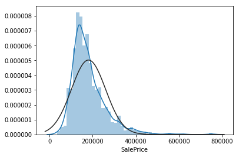

```python
sns.distplot(training_raw['SalePrice'], fit=norm)
```

Wyrysowuję dwa wykres QQ, który zestawie ze sobą kwantyle dwóch rozkładów:

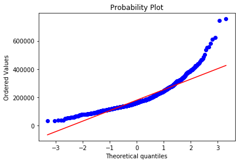

```python
fig = plt.figure()
res = stats.probplot(training_raw['SalePrice'], plot=plt)
```

Jako, że nie występują wartości równe 0 mogę dokonać transformacji logarytmem:

```python
training_raw['SalePrice'] = np.log(training_raw['SalePrice'])
```

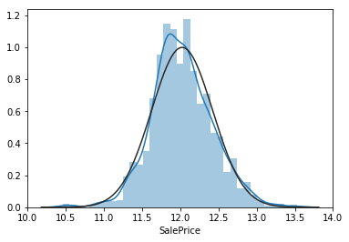

```python
sns.distplot(training_raw['SalePrice'], fit=norm)
```

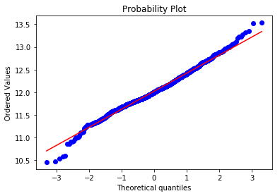

```python
fig = plt.figure()
res = stats.probplot(training_raw['SalePrice'], plot=plt)
```

Zapisuję zmienną zależną oddzielnie i usuwam ją z treningowej ramki danych. Tworzę ramkę danych ze zmiennymi niezależnymi zbioru treningowego:

```python
y = training_raw['SalePrice'].reset_index(drop=True)
train_indep_vars = training_raw.drop(['SalePrice'], axis=1)
```

```python
test_indep_vars = test_raw
```

Sprawdzam brakujące dane oznacze przez `Nan`. Okazuje się, że w zestawach treningowym i testowym braki są przeważnie w tych samych kolumnach, ale zdarzają się wyjątki:

```python
total_missing_train = training_raw.isnull().sum().sort_values(ascending=False)
percentage_missing_train = (training_raw.isnull().sum()/training_raw.shape[0]).sort_values(ascending=False)
missing_data_train = pd.concat([total_missing_train, percentage_missing_train], axis=1, keys=['Total', 'Percentage'])
missing_data_train.head(20)
```

|  | Total | Percentage |
| --- | --- | --- |
| PoolQC | 1453 | 0.995205 |
| MiscFeature | 1406 | 0.963014 |
| Alley | 1369 | 0.937671 |
| Fence | 1179 | 0.807534 |
| FireplaceQu | 690 | 0.472603 |
| LotFrontage | 259 | 0.177397 |
| GarageType | 81 | 0.055479 |
| GarageCond | 81 | 0.055479 |
| GarageFinish | 81 | 0.055479 |
| GarageQual | 81 | 0.055479 |
| GarageYrBlt | 81 | 0.055479 |
| BsmtFinType2 | 38 | 0.026027 |
| BsmtExposure | 38 | 0.026027 |
| BsmtQual | 37 | 0.025342 |
| BsmtCond | 37 | 0.025342 |
| BsmtFinType1 | 37 | 0.025342 |
| MasVnrArea | 8 | 0.005479 |
| MasVnrType | 8 | 0.005479 |
| Electrical | 1 | 0.000685 |
| RoofMatl | 0 | 0.000000 |

```python
total_missing_test = test_raw.isnull().sum().sort_values(ascending=False)
percentage_missing_test = (test_raw.isnull().sum()/test_raw.shape[0]).sort_values(ascending=False)
missing_data_test = pd.concat([total_missing_test, percentage_missing_test], axis=1, keys=['Total', 'Percentage'])
missing_data_test.head(20)
```

|  | Total | Percentage |
| --- | --- | --- |
| PoolQC | 1456 | 0.997944 |
| MiscFeature | 1408 | 0.965045 |
| Alley | 1352 | 0.926662 |
| Fence | 1169 | 0.801234 |
| FireplaceQu | 730 | 0.500343 |
| LotFrontage | 227 | 0.155586 |
| GarageCond | 78 | 0.053461 |
| GarageFinish | 78 | 0.053461 |
| GarageYrBlt | 78 | 0.053461 |
| GarageQual | 78 | 0.053461 |
| GarageType | 76 | 0.052090 |
| BsmtCond | 45 | 0.030843 |
| BsmtExposure | 44 | 0.030158 |
| BsmtQual | 44 | 0.030158 |
| BsmtFinType1 | 42 | 0.028787 |
| BsmtFinType2 | 42 | 0.028787 |
| MasVnrType | 16 | 0.010966 |
| MasVnrArea | 15 | 0.010281 |
| MSZoning | 4 | 0.002742 |
| BsmtHalfBath | 2 | 0.001371 |

Łączę zestaw treningowy i testowy na czas przerabiania i wypełniania zmiennych:

```python
indep_vars = pd.concat([train_indep_vars, test_indep_vars]).reset_index(drop=True)
```

```python
indep_vars.shape
```

```
(2919, 79)
```

Warto zauważyć, że niektóre zmienne, które są na skali numerycznej oznaczają tak naprawdę kategorie, które można uporządkować w kolejności, ale nie można stwierdzić czy odstęp pomiędzy róznymi parami wartości jest równy:

```python
indep_vars['MSSubClass'] = indep_vars['MSSubClass'].apply(str)
indep_vars['MoSold'] = indep_vars['MoSold'].apply(str)
```

Najczęściej brakuje zmiennej `PoolQC`, która informuje o tym czy nieruchomość ma basen. Jako, że większość nieruchomości basenu nie ma dodaję inną wartość niż `NaN`, ale przekazującą tą samą wiadomość:

```python
indep_vars['PoolQC'] = indep_vars['PoolQC'].fillna("None")
```

Brakuje także danych dotyczących garażu. Liczbowe zastępuję zerami, ponieważ gdy nie ma garażu, garaż nie ma powierzchni:

```python
for col in ['GarageYrBlt GarageArea GarageCars'.split()]:
    indep_vars[col] = indep_vars[col].fillna(0)
```

```python
for col in ['GarageType GarageFinish GarageQual GarageCond'.split()]:
    indep_vars[col] = indep_vars[col].fillna("None")
```

W przypadku domów bez piwnic zmienne kategoryczne uzupełniam informacją o braku piwnicy:

```python
for col in ['BsmtQual BsmtCond BsmtExposure BsmtFinType1 BsmtFinType2'.split()]:
    indep_vars[col] = indep_vars[col].fillna("None")
```

```python
for col in ['Fence Alley MiscFeature FireplaceQu KitchenQual'.split()]:
    indep_vars[col] = indep_vars[col].fillna("None")
```

```python
for col in ['BsmtHalfBath BsmtFullBath BsmtUnfSF BsmtHalfBath BsmtFinSF1 TotalBsmtSF BsmtFinSF2'.split()]:
    indep_vars[col] = indep_vars[col].fillna(0)
```

```python
indep_vars['MasVnrArea'].fillna(0, inplace=True)
indep_vars['MasVnrType'].fillna('None', inplace=True)
```

LotFrontage: Linear feet of street connected to property

```python
indep_vars['LotFrontage'] = indep_vars.groupby('Neighborhood')['LotFrontage'].transform(lambda x: x.fillna(x.mode()[0]))
```

```python
indep_vars['MSZoning'] = indep_vars.groupby('MSSubClass')['MSZoning'].transform(lambda x: x.fillna(x.mode()[0]))
```

Zmienne, dla których nie przewidziano braku wartości wypełniam dominantą:

```python
indep_vars['Utilities'].fillna(indep_vars['Utilities'].mode()[0], inplace=True)
```

```python
indep_vars['Electrical'].fillna(indep_vars['Electrical'].mode()[0], inplace=True)
```

```python
indep_vars['Exterior1st'].fillna(indep_vars['Exterior1st'].mode()[0], inplace=True)
indep_vars['Exterior2nd'].fillna(indep_vars['Exterior2nd'].mode()[0], inplace=True)
```

Jeszcze inne zmienne w legendzie mają określony domyślny poziom dlatego zastąpienie wartości brakujących powinno nastąpić właśnie nimi:

```python
indep_vars['Functional'].fillna('Typ', inplace=True)
```

```python
indep_vars['SaleType'].fillna('Oth', inplace=True)
```

```python
indep_vars.isnull().sum().sort_values(ascending=False).head()
```

```
SaleCondition    0
Foundation       0
RoofMatl         0
Exterior1st      0
Exterior2nd      0
dtype: int64
```

Wybieram zmienne numeryczne, które powinny mieć rozkład normalny:

```python
num_dtypes = ['int16', 'int32', 'int64', 'float16', 'float32', 'float64']
numerical_vars = [col for col in indep_vars.columns if indep_vars[col].dtype in num_dtypes]
```

```python
numerical_vars
```

```
['LotFrontage',
 'LotArea',
 'OverallQual',
 'OverallCond',
 'YearBuilt',
 'YearRemodAdd',
 'MasVnrArea',
 'BsmtFinSF1',
 'BsmtFinSF2',
 'BsmtUnfSF',
 'TotalBsmtSF',
 '1stFlrSF',
 '2ndFlrSF',
 'LowQualFinSF',
 'GrLivArea',
 'BsmtFullBath',
 'BsmtHalfBath',
 'FullBath',
 'HalfBath',
 'BedroomAbvGr',
 'KitchenAbvGr',
 'TotRmsAbvGrd',
 'Fireplaces',
 'GarageYrBlt',
 'GarageCars',
 'GarageArea',
 'WoodDeckSF',
 'OpenPorchSF',
 'EnclosedPorch',
 '3SsnPorch',
 'ScreenPorch',
 'PoolArea',
 'MiscVal',
 'YrSold']
```

```python
tmp_train_indep_vars = indep_vars.iloc[:len(y), :]
```

```python
skewness = tmp_train_indep_vars[numerical_vars].apply(lambda x: skew(x)).sort_values(ascending=False)
```

```python
skewness
```

```
MiscVal          24.451640
PoolArea         14.813135
LotArea          12.195142
3SsnPorch        10.293752
LowQualFinSF      9.002080
KitchenAbvGr      4.483784
BsmtFinSF2        4.250888
ScreenPorch       4.117977
BsmtHalfBath      4.099186
EnclosedPorch     3.086696
MasVnrArea        2.674865
OpenPorchSF       2.361912
LotFrontage       2.175420
BsmtFinSF1        1.683771
WoodDeckSF        1.539792
TotalBsmtSF       1.522688
1stFlrSF          1.375342
GrLivArea         1.365156
BsmtUnfSF         0.919323
2ndFlrSF          0.812194
OverallCond       0.692355
TotRmsAbvGrd      0.675646
HalfBath          0.675203
Fireplaces        0.648898
BsmtFullBath      0.595454
OverallQual       0.216721
BedroomAbvGr      0.211572
GarageArea        0.179796
YrSold            0.096170
FullBath          0.036524
GarageCars       -0.342197
YearRemodAdd     -0.503044
YearBuilt        -0.612831
GarageYrBlt      -3.865524
dtype: float64
```

Warto pamiętać, że w niektórych zmiennych skośność rozkładu powstała w wyniku wypełnienia brakujących zmiennych zerami:

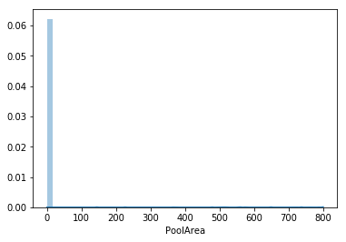

```python
sns.distplot(indep_vars['PoolArea'])
```

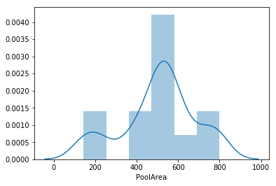

```python
sns.distplot(indep_vars['PoolArea'].loc[indep_vars['PoolArea'] > 0])
```

Za zbyt skośne uznaję zmienne, których skośność (wartość bezwzględna) jest większa lub równa 1:

```python
high_skew_vars = skewness[np.abs(skewness) >= 1]

for col in high_skew_vars.index:
    try:
        indep_vars[col] = boxcox1p(indep_vars[col], boxcox_normmax(indep_vars[col] + 1))
    except:
        pass
```

Tworze własne zmienne typu:

```python
indep_vars['hasPool'] = indep_vars['PoolArea'].apply(lambda x: 1 if x > 0 else 0)
indep_vars['has2ndFloor'] = indep_vars['2ndFlrSF'].apply(lambda x: 1 if x > 0 else 0)
indep_vars['hasGarage'] = indep_vars['GarageArea'].apply(lambda x: 1 if x > 0 else 0)
indep_vars['hasBasement'] = indep_vars['TotalBsmtSF'].apply(lambda x: 1 if x > 0 else 0)
indep_vars['hasFirePlace'] = indep_vars['Fireplaces'].apply(lambda x: 1 if x > 0 else 0)
```

```python
indep_vars['YrTotal'] = indep_vars['YearBuilt'] + indep_vars['YearRemodAdd']
indep_vars['TotalSF'] = indep_vars['TotalBsmtSF'] + indep_vars['1stFlrSF'] + indep_vars['2ndFlrSF']
indep_vars['TotalBathrooms'] = indep_vars['FullBath']  + 0.5 * indep_vars['HalfBath'] + indep_vars['BsmtFullBath'] + 0.5 * indep_vars['BsmtHalfBath']
```

```python
indep_vars['Total_porch_sf'] = indep_vars['OpenPorchSF'] \
+ indep_vars['3SsnPorch'] +\
indep_vars['EnclosedPorch'] \
+ indep_vars['ScreenPorch'] \
+ indep_vars['WoodDeckSF']
```

Ze zmiennych kategorycznych tworzę one-hot encoded:

```python
indep_vars_final = pd.get_dummies(indep_vars).reset_index(drop=True)
```

```python
X_train = indep_vars_final.iloc[:len(y), :]
X_test = indep_vars_final.iloc[len(X_train):, :]
```

Meta: skończyłem na `print('X', X.shape, 'y', y.shape, 'X_sub', X_sub.shape)`

```python
print('X', X_train.shape, 'y', y.shape, 'X_sub', X_test.shape)
```

```
X (1460, 338) y (1460,) X_sub (1459, 338)
```

Ze zbioru danych treningowych usuwam obserwacje odstające:

```python
outliers = []
```

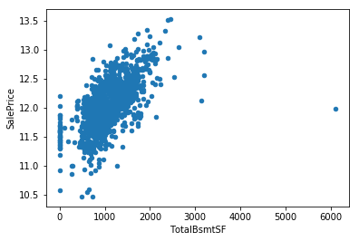

```python
training_raw.plot.scatter(x='TotalBsmtSF', y='SalePrice')
```

```python
outliers.extend(training_raw.loc[training_raw['TotalBsmtSF'] > 6000].index)
```

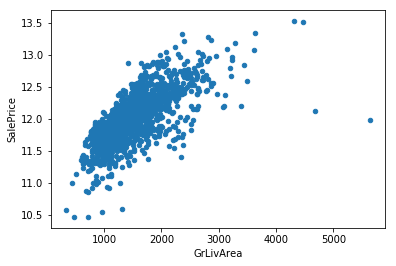

```python
training_raw.plot.scatter(x='GrLivArea', y='SalePrice')
```

```python
outliers.extend(training_raw.loc[(training_raw['GrLivArea'] > 4000) & (training_raw['SalePrice'] < 12.5)].index)
```

```python
outliers
```

```
[1298, 523, 1298]
```

Usuwam z zestawu dwie obserwacje:

```python
outliers = []
```

```python
X_train['tmp_SalePrice'] = y
```

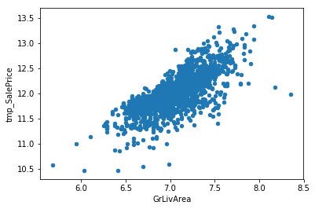

```python
X_train.plot.scatter(x='GrLivArea', y='tmp_SalePrice')
```

```python
outliers.extend(X_train.loc[(X_train['GrLivArea'] > 8) & (X_train['tmp_SalePrice'] < 12.5)].index)
```

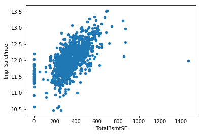

```python
X_train.plot.scatter(x='TotalBsmtSF', y='tmp_SalePrice')
```

```python
outliers.extend(X_train.loc[X_train['TotalBsmtSF'] > 1400].index)
```

```python
del X_train['tmp_SalePrice']
X_train = X_train.drop(X_train.index[outliers])
y = y.drop(y.index[outliers])
```

## Definiowanie modeli

Tworzę dwa modele:

```python
lightgbm = LGBMRegressor(objective='regression',
                                       num_leaves=16,
                                       learning_rate=0.01,
                                       n_estimators=5000,
                                       max_depth=8,
                                       verbose=-1
                                       )
```

```python
xgboost = XGBRegressor(learning_rate=0.01, n_estimators=3460,
                                     max_depth=3,
                                     subsample=0.75,
                                     objective='reg:linear',
                                     nthread=-1)
```

```python
lgb_model_full_data = lightgbm.fit(X_train, y)
```

```python
xgboost_fitted = xgboost.fit(X_train, y)
```

```
[04:51:25] WARNING: /workspace/src/objective/regression_obj.cu:152: reg:linear is now deprecated in favor of reg:squarederror.
```

```python
def get_models_average(X_test):
    return 0.5 * xgboost_fitted.predict(X_test) \
            + 0.5 * lgb_model_full_data.predict(X_test)
```

```python
submission = pd.read_csv("./data/sample_submission.csv")
submission.iloc[:,1] = np.exp(get_models_average(X_test))
```

```python
get_models_average(X_test)
```

```
array([11.73294902, 11.97592137, 12.13065886, ..., 11.99349478,
       11.66966027, 12.32303503])
```

```python
submission.to_csv("2_models_sub.csv", index=False)
```